# Hypothesis-Free 개론

Hanbin Lee

2019년 3월 10일

- 이 문서는 Rmarkdown을 사용하여 작성됐습니다.

# Hypothesis-Free의 필요성: Genetic Association Study를 중심으로

*Hypothesis-Free*는 최근 유전학(Genetics)와 역학(Epidemiology) 분야에서 자주 보이는 용어 중 하나입니다. 유전학에서는 Genome-Wide Association Study(GWAS), 환경역학에서는 Exposure-Wide Association Study(EWAS) 등의 형태로 많이 소개됩니다. 비슷한 것들로 Epigenome-Wide, Environment-Wide 등이 있습니다. 입자물리학을 전공하는 지인에 따르면 자기 분야에서도 오래 전부터 제기된 방법론이라고 하네요. 이 단락에서는 Genetic Association Study의 사례를 중심으로 왜 Hypothesis-Free 연구가 대두되었는지 설명하겠습니다.

## Candidate-Gene Approach: 가설 기반 연구의 한계

유전자와 형질 사이의 관계는 오랫동안 과학자들의 관심사였습니다. 특히, 저 같이 의학을 전공하는 사람들에게는 질병의 원인이 되는 유전자를 찾는 것이 굉장히 중요한 문제였습니다. 그러나 1953년에 DNA가 발견된 뒤에도 이것은 굉장히 오랫동안 어려운 과제로 남았습니다. 왜냐하면 DNA 정보를 읽는 것이 굉장히 어려웠기 때문입니다. 그러나 잘 알려져 있다시피 Sanger 등에 의해 DNA 염기서열을 읽을 수 있는 방법들이 연이어 개발됐고 이에 힘업어 유전자-형질 관계를 밝히고자 하는 연구들이 등장했습니다. 대표적인 사례가 바로 *APOE* 라는 유전자로 치매(정확히는 알츠하이머)와 관련이 되었음이 일찍히 밝혀졌습니다(Strittmatter et al. 1993).

이러한 연구들의 특징 중 하나는 유전체(Genome)의 일부만을 읽었다는 점입니다. DNA를 읽을 수 있는 기술이 개발되었음에도 기술적인 난도와 엄청난 비용 때문에 유전체 전체를 읽을 수 있는 방법이 없었기 때문입니다. 따라서 연구자들은 선행연구를 바탕으로 질병과 관련이 있을 것으로 추정되는 유전자들을 미리 선별한 다음 그 유전자들의 정보만 읽는 방법을 택했습니다. 이를 Candidate-Gene Approach라고 하는데 우리말로 후보-유전자 방법이라고 합니다. 이름에서 알 수 있는 것처럼 후보가 될만한 유전자를 추려서 그 유전자들만 조사하는 방법입니다.

그러나 2000년대 초반을 지나면서 Candidate-Gene Approach의 한계를 지적하는 연구들이 쏟아지기 시작합니다. 가장 핵심적인 비판점 중 하나는 Candidate-Gene Approach를 통해 이뤄진 연구들이 재현되지 않는다는 사실이었습니다. 이는 후속 연구에서 기존 연구 결과가 반복적으로 확인되지 않는다는 뜻입니다(J. N. Hirschhorn et al. 2002; J. P. A. Ioannidis 2005; K. E. Lohmueller et al. 2003). 특히 J. N. Hirschhorn et al. (2002) 에서는 Candidate-Gene Approach에 기반하는 166개의 연구를 조사한 결과 오직 6개만이 재현(75% 이상 재현)되며 97개는 오직 한 번만, 그리고 63개는 단 한 번도 재현되지 않는다는 것을 확인했습니다. 이로인해 Candidate-Gene Approach는 신뢰할 수 없는 방법론이라는 것이 점점 알려지게 됩니다.

그러면 왜 Candidate-Gene Approach는 재현성 문제에 시달릴 수 밖에 없었던 것일까요? 여기에는 굉장히 많은 이유가 있으나 두 가지만 소개하도록 하겠습니다. 더 자세한 논의는 Statistical Genetics (B. Neale 2008)를 읽어주세요.

### 원인 1: Population Substructure/Admixture

O형이 다른 혈액형보다 청국장을 싫어한다면 이를 믿으시겠습니까? 그러나 이 허무맹랑한 주장을 통계적으로 입증할 방법이 있습니다.

[figure not shown]

그림1. 국가별 혈액형 분포

위 사진은 국가별 혈액형 분포를 보여주고 있습니다. 출처는 TV 예능이니 예시를 위한 Toy Model 정도로만 생각해주세요.

저는 연구를 위해 한국인 100명, 페루 원주민 100명을 선발했습니다. 저는 다음의 회귀분석을 시행할 것입니다.

$$logit(y_{청국장좋아함}) = \beta_{O형} \cdot x_{O형} + c(상수)+ \epsilon$$

즉, O형인가 여부에 따라 청국장을 얼마나 더 좋아하는지 알아보는 것입니다. 만약 O형이 청국장을 싫어한다면 $\beta_{O형}$은 음수겠죠. 한국인 중 청국장을 좋아하는 사람을 50%라고 가정하고 페루 원주민 중에는 먹어본 사람이 거의 없을테니 5%라고 가정하겠습니다. 이 때 회귀분석의 결과는 어떻게 될까요?

```r
# 한국인 샘플링: 청국장 선호와 혈액형은 독립
x.kor <- rbinom(100, 1, 0.28) # O형은 28%
y.kor <- rbinom(100, 1, 0.5) # 청국장 좋아하는 사람 50%

# 페루 원주민 샘플링: 청국장 선호와 혈액형은 독립
x.per <- rbinom(100, 1, 0.95) # O형 95%
y.per <- rbinom(100, 1, 0.05) # 청국장 좋아하는 사람 5%

# 회귀분석
x <- c(x.kor, x.per)
y <- c(y.kor, y.per)
fit <- glm(y~x, family="binomial")
print(summary(fit))
```

```
##
## Call:
## glm(formula = y ~ x, family = "binomial")
##
## Deviance Residuals:
##     Min       1Q   Median       3Q      Max
## -1.2537  -0.5326  -0.5326   1.1030   2.0116
##
## Coefficients:
##             Estimate Std. Error z value Pr(>|z|)
## (Intercept)   0.1777     0.2259   0.787    0.432
## x            -2.0591     0.3508  -5.870 4.37e-09 ***
## ---
## Signif. codes:  0 '***' 0.001 '**' 0.01 '*' 0.05 '.' 0.1 ' ' 1
##
## (Dispersion parameter for binomial family taken to be 1)
##
##     Null deviance: 242.63  on 199  degrees of freedom
## Residual deviance: 203.42  on 198  degrees of freedom
## AIC: 207.42
##
## Number of Fisher Scoring iterations: 4
```

그런데 이 분석을 한국인과 페루인에서 따로 진행하면 어떤 결과가 나올까요?

```r
# 회귀분석
fit.kor <- glm(y.kor~x.kor, family="binomial")
fit.per <- glm(y.per~x.per, family="binomial")
print(summary(fit.kor))
```

```
##
## Call:
## glm(formula = y.kor ~ x.kor, family = "binomial")
##
## Deviance Residuals:
##    Min      1Q  Median      3Q     Max
## -1.279  -1.279   1.079   1.079   1.215
##
## Coefficients:
##             Estimate Std. Error z value Pr(>|z|)
## (Intercept)   0.2348     0.2295   1.023    0.306
## x.kor        -0.3219     0.4763  -0.676    0.499
##
## (Dispersion parameter for binomial family taken to be 1)
##
##     Null deviance: 137.99  on 99  degrees of freedom
## Residual deviance: 137.53  on 98  degrees of freedom
## AIC: 141.53
##
## Number of Fisher Scoring iterations: 3
```

```r
print(summary(fit.per))
```

```
##
## Call:
## glm(formula = y.per ~ x.per, family = "binomial")
##
## Deviance Residuals:
##     Min       1Q   Median       3Q      Max
## -0.3236  -0.3236  -0.3236  -0.3236   2.4395
##
## Coefficients:
##             Estimate Std. Error z value Pr(>|z|)
## (Intercept)   -17.57    2797.44  -0.006    0.995
## x.per          14.64    2797.44   0.005    0.996
##
## (Dispersion parameter for binomial family taken to be 1)
##
##     Null deviance: 39.703  on 99  degrees of freedom
## Residual deviance: 39.496  on 98  degrees of freedom
## AIC: 43.496
##
## Number of Fisher Scoring iterations: 16
```

보시다시피 단 한 개도 유의하지 않은 것을 관찰할 수 있습니다. 데이터를 만들 때 종속변수(청국장선호)와 독립변수(O형여부)가 독립이 되도록 했으니 당연한 일입니다. 문제는 두 집단에 대한 분석을 하나의 데이터로 합쳤을 때 발생했죠.

그런데 이런 문제는 Association Study에서 항상 발생합니다. 진화적으로 오래 전에 분기한 두 집단을 한 데이터에 포함했기 때문이죠. 페루 원주민과 한국인을 섞어서 분석한 상단의 사례처럼 말입니다. O형 유전자가 아니더라도 한국인에서 페루인보다 적게 발견되는 유전자를 분석에 넣으면 항상 그 유전자가 청국장 선호도를 감소시킨다는 결과를 얻을 것입니다. 이 현상의 가장 큰 원인은 바로 *유전적 부동(Genetic Drift)* 입니다. 아무런 요소가 개입하지 않더라도 집단의 유전자 빈도(Gene Frequency)는 무작위로 오르내립니다. 주식시장에서 주가가 출렁이는 것처럼 말이죠(실제로 유전자 빈도를 연구하는 수학은 주식시장에서 주가를 예측하는 수학과 동일합니다). 그 결과 우연히 두 집단 사이의 유전자 빈도가 달라질 경우에는 상단의 결과처럼 이상한 결과를 얻는 것입니다. 따라서 정확한 분석 결과를 얻기 위해서는 한국인과 페루 원주민을 분리해서 분석했던 것처럼 비슷한 집단 안에서만 분석을 진행해야합니다.

그런데 한 나라 안에서도 굉장히 다양한 집단에서 유래한 사람들이 삽니다. 전 대륙의 사람들이 모이는 미국은 말할 것도 없고 같은 유럽 백인 안에서도 상당한 차이가 있습니다(Berg et al. 2018). 고대부터 몽골, 거란, 여진 등의 침략을 끊임없이 받아온 한국도 크게 다르지 않을 것입니다. 이러한 유전적 차이를 Ancestry라고 부르고 서로 다른 Ancestry를 가진 사람들이 섞여 있는 것을 Population Substructure이나 Population Admixture이라고 부릅니다(Substructure은 단순히 같이 섞여 살기만 하는 것, Admixture은 섞여 살면서 발생한 혼혈이 다수 존재하는 것을 말합니다). 문제는 데이터에 서로 다른 Ancestry를 가진 사람들이 섞여있는지 알 방법이 없다는 점입니다.

### 원인 2: Publication Bias

다른 원인 중 하나는 바로 *Publication Bias(출판편향)*입니다. 연구자들이 연구를 하다가 결과가 마음에 들면 출판을 하고 마음에 안 들면 출판하지 않아 발생하는 편향입니다. 예를 들어, 물약 A가 치매 치료에 효과가 있다는 연구가 100번 이뤄졌는데 50번은 효과가 있으며 50번은 효과가 없다는 결과가 나왔다고 가정합시다. 이 때 효과가 있다는 논문만 출판될 경우 바깥에서 보는 사람들은 물약 A가 효과가 있다고 믿게 되겠죠.

학계에 존재하는 Publication Bias는 오래 전부터 제기되었습니다. 의학의 경우(Perneger and Combescure 2017), 심리학의 경우(Schimmack 2012) 등 학문과 분야를 가리지 않고 폭넓게 발견되는 현상입니다. 그 원인에 대해서는 다양한 논의가 있으나 여기서는 생략토록 하겠습니다. 중요한 것은 Candidate-Gene Approach도 이로부터 자유롭지 않다는 점입니다.

## Genome-Wide Association Study (GWAS)의 등장

Candidate-Gene Approach를 어떻게 극복할 것인가를 두고 많은 논의가 있었고 기술적 발전에 힘업어 Genome-Wide Association Study (GWAS)가 제안됩니다. GWAS는 이름처럼 유전체의 모든 유전자와 형질의 관계를 확인하는 방식입니다. 특정 후보 유전자만 골라서 검정하는 방식과 대조적이죠. 그래서 GWAS는 후보 유전자를 특정하는 가설에 의존하지 않는다는 점에서 Hypothesis-Free한 방법론으로 일컬어집니다. 이는 유전체 전체(Genome-Wide)를 읽을 수 있는 SNP Microarray 등이 개발되면서 가능해졌습니다. 이러한 기술은 최근 들어 더욱 발전하여 WES(Whole Exome Sequencing)나 WGS(Whole Genome Seqeuencing) 등으로 이어지고 있습니다. 그러면 GWAS가 Candidate-Gene Approach의 한계를 어떻게 극복하는지에 앞서 GWAS가 어떤 원리로 가능한지 알아보도록 하겠습니다.

### GWAS의 생물학적 원리

생명과학을 전공하는 입장에서 GWAS가 중요한 이유 중 하나는 이것이 단순히 통계적으로 고도화된 방법을 사용하는 것을 넘어 생물학의 핵심적인 성과를 모두 종합하기 때문입니다. GWAS는 게놈프로젝트와 뒤이어 진행된 반수체지도프로젝트(Haploid Map Project, 2005)의 성과가 없었다면 GWAS는 절대로 불가능했을 것입니다.

앞서 설명했듯이 GWAS는 Genome-Wide하게 유전자-형질 상관관계를 측정합니다. 단순히 통계적으로만 생각하면 인간 유전체는 약 30억개의 염기로 이뤄져 있고 30억개의 염기가 모두 변이의 가능성을 갖고 있기 때문에 진정한(?) Genome-Wide는 30억개 염기에 존재하는 모든 변이의 가능성을 고려해야합니다. 그런데 이는 GWAS가 태동하던 시절의 시퀀싱 능력의 문제 및 다중비교로 인한 검정력 손실 등의 문제로 절대로 불가능한 설계였습니다. 그런데 우리는 통계학 뿐만 아니라 생물학을 알고 있었습니다. 생물학에 따르면 우리의 유전체에는 연관(Linkage)과 교차(Crossover)이라는 현상이 있으므로 30억개의 염기를 모두 조사할 필요가 없어집니다.

구체적으로 설명하면 다음과 같습니다. 인간에게는 23쌍의 염색체가 존재하는데 각각의 염색체는 독립적으로 유전됩니다. 그리고 한 염색체 안에 있는 지역들은 물리적으로 결합되어 있기 때문에 함께 유전됩니다. 이를 연관이라고 하죠. 그렇지만 같은 염색체 안에서도 물리적으로 거리가 멀어질수록 교차에 의해 독립적으로 유전될 확률이 점점 증가합니다. 나아가 어떤 지역은 교차가 활발하게 일어나고 어떤 지역은 교차가 조금 밖에 안 일어납니다. 이를 종합해서 Linkage Disequilibrium라고 부르는데 보통 상관계수 $r^2$를 기준으로 측정합니다. 아래 그림은 $r^2$이 DNA 상의 물리적 거리에 따라 어떻게 변하는지 보여주는 표입니다.

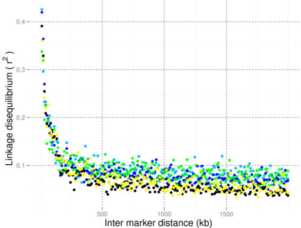

LD와 물리적 거리 사이의 관계 (Sodeland et al. 2011)

이를 모두 종합하면 한 염색체 안에서도 작은 소규모 지역들이 있어서 그 안에서는 뭉쳐다니는데 다른 지역끼리는 독립적으로 유전될 것임을 추측할 수 있습니다. 따라서 이 소규모 지역을 Box라고 부르면 개개인의 염색체는 서로 다른 Box의 조합인데 이를 *반수체(Haploid)*라고 부릅니다. HapMap Project는 이 반수체 지도를 완성시키는 것을 목표로 했던 국제 컨소시엄으로 Box들이 어떻게 분포하는지 확인하는 작업이었습니다.

이 사실이 함의하는 것은, 어짜피 DNA 조각들은 Box 단위로 뭉쳐 다니기 때문에 모든 DNA 지역을 관찰할 필요 없이 Box 단위로 확인하면 유전체 전체(Genome-Wide)를 분석할 수 있다는 것입니다. 예를 들어, 하나의 Box에 두 개의 유전자 X와 Y가 있고 각각이 대립 유전자 A,a 그리고 B,b를 갖는 상황을 생각합시다. 최초에 AB 조합과 ab 조합만이 존재했다면 돌연변이나 교차가 일어나지 않는 상황에서는 오로지 AB와 ab라는 두 가지 반수체만 존재합니다. 그러면 유전자 X에 대립유전자 A가 존재하면 같은 상자 안에 있는 유전자 Y는 대립유전자 B일 것이라는 걸 바로 알 수 있습니다. 따라서 유전자 X와 유전자 Y의 변이를 모두 확인할 필요 없이 둘 중 하나만 확인하면 되는 것입니다. 실제로는 Box 안에 훨씬 많은 수의 유전자가 존재하므로 조사해야하는 DNA 염기의 갯수는 훨씬 줄어들겠죠. 남은 문제는 Box 안에서 어떤 유전자나 위치를 조사할 것인가인데 보통 시퀀싱을 할 때 오류가 적게 나는 위치를 선정합니다. 그리고 이를 마커(Marker)이라고 부릅니다. 현재 GWAS에서는 보편적으로 약 30만개 가량의 Marker면 유전체 전체를 덮을 수 있다고 보고 있습니다.

그러면 다시 본론으로 돌아오면 GWAS의 강점 중 하나는 바로 높은 재현성과 신뢰도입니다. Candidate-Gene Approach와 다르게 반복된 연구에서 지속적으로 확인되는 탄탄함을 갖췄다는 점입니다(Visscher et al. 2017). 그렇다면 GWAS는 어떻게 Candidate-Gene Approach의 한계를 극복할 수 있었을까요?

### Publication Bias에 대한 저항성

GWAS는 단일 연구로도 Publication Bias에 대한 저항성을 갖고 있습니다. 왜냐하면 모든 유전자에 대해서 검정을 진행하기 때문에 어떤 유전자는 보고하고 어떤 유전자는 보고 안 하는 밑장빼기가 원천적으로 불가능하기 때문입니다.

### Population Substructure 탐지

#### Quantile-Quantile Plot (Q-Q plot)

대부분의 유전자는 형질과 상관이 없거나 매우 작은 영향만 미칩니다. 따라서 유전자와 형질의 관계를 측정하다보면 대부분의 유전자는 형질과 상관없는 것으로 나와야겠죠. 문제는 population substructure가 존재할 경우 상관없는 유전자들이 상관이 있다고 나온다는 점입니다. 우리는 이미 혈액형-청국장을 예시로 이 현상을 확인한 바 있습니다. 그렇다면 연구에서 발견한 유전자-형질 상관관계가 진짜인지 population substructure에 의한 가짜인지 구분할 필요가 있으며 GWAS에서는 Candidate-Gene Approach와 다르게 이 일이 가능합니다.

하단의 그림은 유전체 분석 플랫폼인 [Hail](https://hail.is/)의 Documentation에서 가져온 그림입니다.

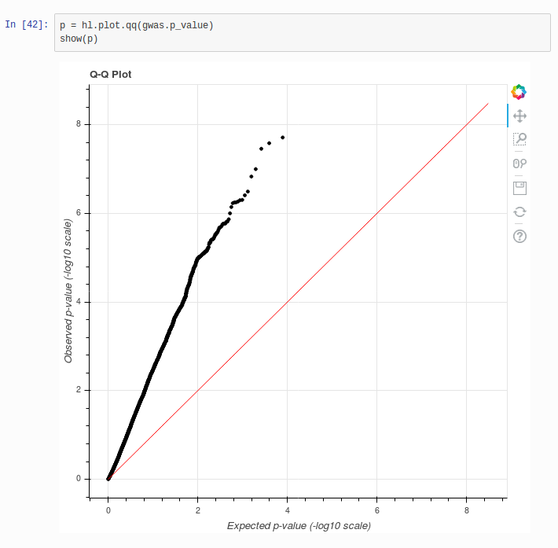

그림 2. Population substructure이 존재하는 GWAS 분석 결과를 요약한 Q-Q plot

Q-Q plot은 각각의 유전자에 대한 검정의 실제 p-value를 $y$-축, 영 가설 하에서의 p-value의 기댓값을 $x$-축에 두고 점을 찍은 그림입니다. 우리가 기대하는 것처럼 대부분의 유전자가 형질과 상관이 없다면 대부분의 점은 빨간색 선 위에 올라가야 합니다. 그런데 그림 2에서 보시다시피 대부분 점들이 빨간선을 벗어난 것을 볼 수 있습니다. 즉, 해당 결과는 실제로 존재하는 유전자-형질 상관관계가 아니라 population substructure에 의한 가짜 신호라는 것을 알 수 있습니다.

Candidate-Gene Approach의 경우 그림에 찍을 수 있는 점이 하나 밖에 없기 때문에 그 점이 실제 유전자-형질 상관관계 때문에 예외적으로 빨간색 선에서 벗어난 것인지 population substructure에 의해 다 같이 벗어난 점 중 하나인지 알 수가 없죠. 반면, GWAS는 점을 여러 개 찍을 수 있기 때문에 전체적인 분포를 보고 우리가 발견한 상관관계가 진짜인지 아닌지 판단할 수 있는 하나의 기준을 제시해줍니다.

#### Principal Component Analysis (PCA)

Population substructure가 존재한다는 것을 알았다면 이를 고칠 방법이 필요합니다. 이 때 흔히 쓰는 방법이 Principal Component Analysis (PCA)로 굉장히 효율적으로 population structure을 보정할 수 있다는 것이 알려져 있습니다(Price et al. 2006). 최근 연구에 따르면 PCA 역시 상황에 따라서 몇 가지 한계가 있긴 합니다(Berg et al. 2018). 그럼 다시 Hail의 Documentation에 등장하는 그림으로 넘어갑시다.

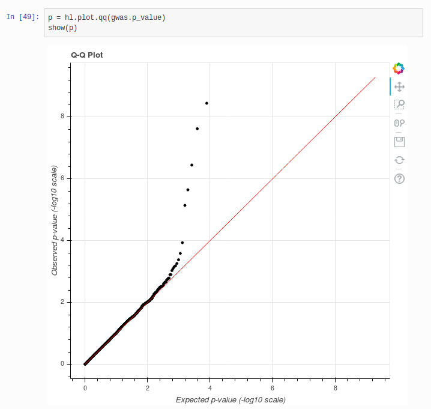

그림 3. Population substructure을 보정한 GWAS 분석 결과를 요약한 Q-Q plot

그림 2와 다르게 그림 3의 경우 검은점들이 대부분 붉은선 위에 올라가 있는 것을 관찰할 수 있습니다. 우리가 기대했던 것과 일치하는 결과입니다. 이 경우에는 벗어난 점들이 population substructure이 아니라 실제 유전자-형질 상관관계에 의한 것일 가능성이 대단히 높습니다.

#### Linkage Disequilibrium Score Regression (LD score regression)

Q-Q plot에서 보았듯 복수의 검정이 존재할 경우 전체적인 분포를 조사하여 진짜 신호와 가짜 신호를 구분할 수 있습니다. Linkage Disequilibrium Score Regression (LD score regression 혹은 LDSC)은 Marker의 검정 통계량($\chi^2$)이 총 LD에 비례한다는 사실을 이용해 population structure에 의한 가짜 효과와 실제 효과를 분리합니다(Bulik-Sullivan et al. 2015). 이 방법의 회귀모델을 수식으로 쓰면

$$E[\chi^2 | l_j] = Nh^2l_j/M + Na + 1$$
으로 여기서 $N$은 연구에 들어간 샘플수, $l_j = \sum_{k} r_{jk}^{2}$는 주어진 마커가 가지는 LD의 총합, $a$는 통계량($\chi^2$)에 대한 population structure의 기여도입니다. 여기서 통계량이 $\chi^2$인 이유는 회귀분석의 계수 $\beta$가 정규분포를 따라는데 편의상 그것의 제곱인 $\beta^2$의 분포로 가설검정을 시행하기 때문입니다. 표준정규분포의 제곱이 $\chi^2$ 분포라는 것은 수학적으로 잘 알려진 사실이므로 추가적인 설명을 생략하겠습니다. 구체적인 증명은 Bulik-Sullivan et al. (2015) 의 Supplementary Note를 참고하시고 여기서는 생물학적 의미에 대해서만 간략하게 설명하겠습니다.

GWAS의 생물학적 원리를 설명하는 단락에서 우리가 시행하는 검정은 실제로 형질에 효과가 있는 대립유전자 자체가 아니라 그 대립유전자와 같은 Box 안에 포함된 Marker의 효과를 측정하는 것이라고 설명드렸습니다. 따라서 Marker가 $\chi^2$에 기여하는 정도는 Marker가 LD로 묶여있는 Box들의 갯수에 비례할 것으로 예상할 수 있는데 그 비례하는 정도가 정확하게 선형(linear)이라는 것입니다. 뿐만 아니라 population structure에 의한 통계량의 증가는 LD에 의한 실제 효과가 아니기 때문에 LD와 무관하게 모든 마커에 동등하게 기여해야합니다. 그래서 population structure에 의한 항 $a$는 $l_j$에 비례하지 않고 상수항으로 존재하는 것입니다.

따라서 GWAS를 통해 각 Marker의 통계량($\chi^2$)을 구하고 이를 각 마커의 $l_j$로 회귀분석하면 회귀계수 $Nh^2/M$과 상수항 $Na+1$을 얻습니다. 만약 population structure가 없다면($a=0$) 회귀분석으로 구한 상수항이 $1$에 가깝겠죠. 이를 바탕으로 population structure의 존재를 확인하여 population structure에 의한 가짜신호를 전체 신호에서 정량적으로 분리할 수 있는 것입니다. 아래는 조현병 GWAS에 LDSC를 실제로 적용한 사례입니다.

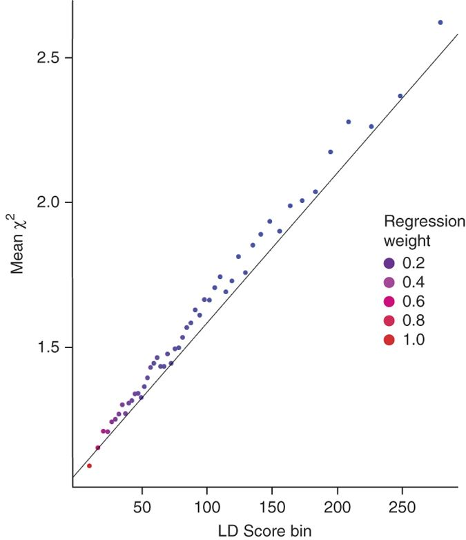

그림 4. 조현병 GWAS 메타분석에 적용한 LDSC (Bulik-Sullivan et al. 2015)

#### 그 외

Genomic Control, Linear Mixed Model 등을 활용한 방법이 있으나 제가 공부가 부족한 관계로 더 공부하고 나면 업데이트 하겠습니다.

### Sampling Scheme의 안정화

#### 충분한 검정력 (Power)

다중비교 때문에 발생하는 검정력 손실은 굉장히 큰 문제였습니다. 현재 연구자들은 각국의 연구자들이 힘을 합쳐 컨소시엄을 구성하거나 (예를 들어, Psychiatric Genomics Consortium) 국가 단위로 대규모 코호트를 구축하는 방식 (예를 들어, UK Biobank)으로 이를 극복하고 있습니다. 최소 수천에서 최대 수십만에 이르는 양질의 데이터가 폭발적으로 생산되고 있으며 한국도 2025년 즈음을 목표로 유전체 코호트 구축이 이뤄지고 있습니다. 중요한 것은 이러한 데이터는 모 분야처럼 인터넷 설문조사나 유의추출로 데이터를 모으는 것이 아니라 다수의 통계학자와 역학자가 국가 지원을 등에 업고 체계적으로 모집한다는 것입니다(Bycroft et al. 2018). 이는 개별 연구자가 기껏해야 수십~수백의 대상자를 바탕으로 연구하던 Candidate-Gene Approach의 시대와는 질적으로 다른 것입니다.

### GWAS가 가져온 변화

제가 이 단락을 주제로 글을 쓸만한 자질이 되는지 굉장히 의심스럽습니다만 현재의 논의와 관련된 것들 위주로 요약하겠습니다.

1. 자체적인 메타 분석

Q-Q plot이나 LDSC 등을 시행함으로써 단일 연구 안에서 자체적인 메타분석을 시행할 수 있습니다. 그 결과, 단일 연구 내부에서 연구의 신뢰도를 평가할 수 있게 됐습니다. Publication Bias가 가져오는 문제도 상당부분 회피할 수 있으므로 더 건강한 연구 관행을 형성하는데에도 도움을 주었습니다. Candidate-Gene Approach에서는 절대로 불가능했을 일입니다.

2. 여러 유사 연구 방법론의 탄생

GWAS의 성공은 가설에 기반한 연구들이 가지는 한계를 보여줬습니다. 그래서 여러 분야에서 GWAS를 모방한 방법론이 등장하는데 후성유전학적 변화를 전체적으로 측정하는 Epigenome-Wide Association Study(EWAS), Exome 지역을 검정하는 Exome-Wide Association Study (EWAS), 질병에 영향을 주는 환경의 영향을 전체적으로 조사하는 Environment-Wide Association Study(EWAS) 등이 그것입니다. 공교롭게도 다 E로 시작하는데 아닌 것도 있으니 너무 심각하게 받아들이지는 마세요. 이러한 방법론들은 연구 재현성과 신뢰도를 위해 가설에 의존하지 않고 가능한 모든 요인을 동시에 평가하는 Hypothesis-Free한 방법론들입니다. 따라서 GWAS가 가지는 강점들을 동일하게 갖추고 있습니다. 한 가지 예로, 사망률에 영향을 미치는 환경적 요인들을 Hypothesis-Free하게 평가한 Patel et al. (2013) 가 있습니다. 반대로 여러 요인에 대해 한 가지 결과를 측정하는 것이 아니라 한 가지 요인에 대해 결과를 동시적으로 측정하는 방법론도 제시됐는데 이를 Phenome-Wide Association Study (PheWAS)라고 합니다. PheWAS의 사례는 [PheWas Catalog](https://phewascatalog.org/)를 참고하면 좋습니다.

3. 진화연구에 가져온 변화 GWAS 이후의 진화 연구 역시 Hypothesis-Free 한 방법론들을 택합니다. 배고픈 유전자 가설의 유전학적 근거가 빈약하다는 사실을 Genome-Wide하게 검정한 Wang and Speakman (2016), 유럽에서 키의 자연선택을 계량하려고 했던 Berg et al. (2018) 등의 최신 집단유전학 연구들은 모두 Hypothesis-Free한 방법론을 택합니다. 이를 통해 신뢰도가 떨어지는 가설기반 연구들의 한계를 극복하고자 하구요.

## 맺음말

지금까지의 논의를 바탕으로 Buss (1989) 를 평가하자면 다음과 같습니다. 해당 연구는 confounder에 통제를 전혀 고려하고 있지 않습니다. 유전학 연구에서 population structure이 문제가 되는 것처럼 여러 사회과학, 심리학 연구에서는 사회경제적 수준 등이 교란요인으로 작용할 수 있고 잘 알려져 있는 사실입니다. 두 번째, 다중비교를 적용하고 있지 않습니다. 이미 예전에 했던 이야기기 때문에 자세한 설명은 생략하겠습니다. 하지만 앞선 논의를 통해 왜 다중비교가 요구되는지는 충분히 설명했다고 봅니다. 세 번째, 내부적 메타분석의 결과가 엉망입니다. 교수님이 지적하신 것과 다르게 단일 연구 내부에서 시행한 동일한 형태의 독립검정을 취합해서 메타분석을 시행하는 사례는 많습니다. GWAS는 그 중에서도 대표적인 사례입니다. 제가 연구에서 등장한 검정의 z-score을 바탕으로 메타분석을 시행했을 때 그 결과는 이전 글에서 제시했듯이 심각한 교란과 부적절한 연구 관행으로 점철되어 있었습니다. 유의기준을 중심으로 나타나는 절벽은 명백히 P-hacking의 증거가 아니면 데이터 상의 하자입니다. 해당 연구의 데이터 추출과정이 무작위 표본 추출이 아니라는 점을 고려할 때 어쩌면 당연한 결과였을지도 모릅니다. 이는 여론조사에서 무작위 추출법보다 더 신뢰할 수 없는 것이지요. 그리고 현재의 토론과 관련하여 드리고 싶은 말씀이 있습니다. 과학을 공부하는 계량연구자는 말이 아니라 숫자로 증명하는 것입니다. 제가 제시한 숫자들에 대한 반론을 제시하지 않으신다면 저도 앞으로 추가 반론을 드릴 생각이 없습니다. 숫자가 아니라 말로만 때우는 건 교수님이 그토록 비판하던 엄밀하지 않은 사회과학에서나 하는 것 아니었나요?

그리고 이 글과 무관하게 한 말씀만 올리고 싶습니다. 교수님의 지난 번 반론글 뿐만 아니라 최근 저서 <진화한 마음>에서 교수님은 항상 피장파장의 오류를 범하십니다. 진화심리학을 다른 사회과학과 비교하면서 때로는 진화심리학을 치켜세우고, 때로는 사회과학도 별로 엄밀하지 않으므로 진화심리학이 특별히 더 공격받을 이유는 없다는 논리죠. 저도 그래서 사회과학 연구 대부분을 믿지 않습니다. 그러나 모든 사회과학 연구를 신뢰하지 않는 것은 아닙니다. 많은 사회과학 연구는 국가에서 생산하는 패널 데이터를 바탕으로 이뤄지며 이 데이터들은 각 국가의 통계청이 설계한 표본 추출법으로 정교하게 생산됩니다. 대부분이 유의추출이나 설문조사에 의존하는 진화심리학 연구와는 비교할 수 없는 수준이지요. 의대 연구에서 사용하는 국가건강영양조사(KNHANES)나 지역사회건강조사(KCHS) 등도 사회경제적 수준과 행동적 변수를 포함한 사회과학적 변수를 포함하지만 통계청과 여러 민간 통계기관이 협력하여 정교한 방식으로 데이터를 생산합니다(Park et al. 2018). 그런 점에서 저는 교수님의 논변들을 저는 좀처럼 이해하기 어렵습니다.

인상비평만으로 타 분야를 깎아내리는 것은 좋은 태도가 아니라고 생각합니다. 만약 사회과학을 비판하고 싶었다면 제가 상단에서 인용한 Schimmack (2012) 처럼 재현성과 같은 문제들을 정확하게 지적할 수 있었겠죠. 그런데 저는 교수님의 책과 글을 읽으면서 이런 엄밀한 지적을 본 적이 없습니다. <진화한 마음>에서 그랬던 것처럼 어떤 사상과 이념에 경도되어 생물학적 분석을 거부하는 미개한 학문이라는 주장만 반복했을 뿐입니다. 그리고 엄밀하게 말하면 교수님이 연구하는 그 분야도 교수님이 그토록 비판하는 사회과학의 한 부류 아닙니까? 진화심리학이 요즘 나오는 진화생물학 연구들처럼 엄밀한 수학적 모델에 기반합니까 아니면 엄격한 통계 방법론에 기반합니까? 그냥 말로 대충 썰풀이하고 정체를 알 수 없는 방법으로 모아진 데이터로 P-hacking이나 일삼는 것이 대체 어떻게 엄격한 자연과학으로 부를 수 있는지 의문입니다. 태도와 전문성의 문제는 제가 아니라 교수님께 있는 것 같습니다.

이한빈 올림.

## 참고문헌

Berg, Jeremy J, Arbel Harpak, Nicholas Sinnott-Armstrong, Anja Moltke Joergensen, Hakhamanesh Mostafavi, Yair Field, Evan A Boyle, et al. 2018. “Reduced Signal for Polygenic Adaptation of Height in UK Biobank,” June. Cold Spring Harbor Laboratory. doi:10.1101/354951.

Bulik-Sullivan, Brendan K, and Po-Ru Loh, Hilary K Finucane, Stephan Ripke, Jian Yang, Nick Patterson, Mark J Daly, Alkes L Price, and Benjamin M Neale. 2015. “LD Score Regression Distinguishes Confounding from Polygenicity in Genome-Wide Association Studies.” *Nature Genetics* 47 (3). Springer Nature: 291–95. doi:10.1038/ng.3211.

Buss, David M. 1989. “Sex Differences in Human Mate Preferences: Evolutionary Hypotheses Tested in 37 Cultures.” *Behavioral and Brain Sciences* 12 (01). Cambridge University Press (CUP): 1. doi:10.1017/s0140525x00023992.

Bycroft, Clare, Colin Freeman, Desislava Petkova, Gavin Band, Lloyd T. Elliott, Kevin Sharp, Allan Motyer, et al. 2018. “The UK Biobank Resource with Deep Phenotyping and Genomic Data.” *Nature* 562 (7726). Springer Nature: 203–9. doi:10.1038/s41586-018-0579-z.

Hirschhorn, Joel N, Kirk Lohmueller, Edward Byrne, and Kurt Hirschhorn. 2002. “A Comprehensive Review of Genetic Association Studies.” *Genetics in Medicine* 4 (2). Springer Nature: 45–61. doi:10.1097/00125817-200203000-00002.

Ioannidis, John P. A. 2005. “Why Most Published Research Findings Are False.” *PLoS Medicine* 2 (8). Public Library of Science (PLoS): e124. doi:10.1371/journal.pmed.0020124.

Lohmueller, Kirk E., Celeste L. Pearce, Malcolm Pike, Eric S. Lander, and Joel N. Hirschhorn. 2003. “Meta-Analysis of Genetic Association Studies Supports a Contribution of Common Variants to Susceptibility to Common Disease.” *Nature Genetics* 33 (2). Springer Nature: 177–82. doi:10.1038/ng1071.

Neale, Benjamin. 2008. *Statistical Genetics: Gene Mapping Through Linkage and Association*. Taylor & Francis. https://www.xarg.org/ref/a/0415410401/.

Park, JooYong, Aesun Shin, Miyoung Lee, Jaesung Choi, Minkyo Song, Yeonjung Kim, Jong-koo Lee, Daehee Kang, and Ji-Yeob Choi. 2018. “Prevalence of Participating in Physical Activity from 2 Korean Surveillance Systems: KNHANES and KCHS.” *Journal of Physical Activity and Health* 15 (10). Human Kinetics: 763–73. doi:10.1123/jpah.2017-0428.

Patel, C. J., D. H. Rehkopf, J. T. Leppert, W. M. Bortz, M. R. Cullen, G. M. Chertow, and J. P. Ioannidis. 2013. “Systematic Evaluation of Environmental and Behavioural Factors Associated with All-Cause Mortality in the United States National Health and Nutrition Examination Survey.” *International Journal of Epidemiology* 42 (6). Oxford University Press (OUP): 1795–1810. doi:10.1093/ije/dyt208.

Perneger, Thomas V., and Christophe Combescure. 2017. “The Distribution of P -Values in Medical Research Articles Suggested Selective Reporting Associated with Statistical Significance.” *Journal of Clinical Epidemiology* 87 (July). Elsevier BV: 70–77. doi:10.1016/j.jclinepi.2017.04.003.

Price, Alkes L, Nick J Patterson, Robert M Plenge, Michael E Weinblatt, Nancy A Shadick, and David Reich. 2006. “Principal Components Analysis Corrects for Stratification in Genome-Wide Association Studies.” *Nature Genetics* 38 (8). Springer Nature: 904–9. doi:10.1038/ng1847.

Schimmack, Ulrich. 2012. “The Ironic Effect of Significant Results on the Credibility of Multiple-Study Articles.” *Psychological Methods* 17 (4). American Psychological Association (APA): 551–66. doi:10.1037/a0029487.

Sodeland, Marte, Matthew Kent, Ben J Hayes, Harald Grove, and Sigbjørn Lien. 2011. “Recent and Historical Recombination in the Admixed Norwegian Red Cattle Breed.” *BMC Genomics* 12 (1). Springer Nature. doi:10.1186/1471-2164-12-33.

Strittmatter, W. J., A. M. Saunders, D. Schmechel, M. Pericak-Vance, J. Enghild, G. S. Salvesen, and A. D. Roses. 1993. “Apolipoprotein E: High-Avidity Binding to Beta-Amyloid and Increased Frequency of Type 4 Allele in Late-Onset Familial Alzheimer Disease.” *Proceedings of the National Academy of Sciences* 90 (5). Proceedings of the National Academy of Sciences: 1977–81. doi:10.1073/pnas.90.5.1977.

Visscher, Peter M., Naomi R. Wray, Qian Zhang, Pamela Sklar, Mark I. McCarthy, Matthew A. Brown, and Jian Yang. 2017. “10 Years of GWAS Discovery: Biology, Function, and Translation.” *The American Journal of Human Genetics* 101 (1). Elsevier BV: 5–22. doi:10.1016/j.ajhg.2017.06.005.

Wang, Guanlin, and John R. Speakman. 2016. “Analysis of Positive Selection at Single Nucleotide Polymorphisms Associated with Body Mass Index Does Not Support the Thrifty Gene Hypothesis.” *Cell Metabolism* 24 (4). Elsevier BV: 531–41. doi:10.1016/j.cmet.2016.08.014.